# Class 7: Politically Violent Activity

Foreign fighters and political violence in authoritarian contexts

[Dr. Michael C. Zeller](https://michaelzeller.de)

# Opening notes

[Open Sticker](https://tenor.com/view/open-gif-14209777)from [Open Stickers](https://tenor.com/search/open-stickers)

## Presentation groups

Presentations line-up

| Date | Presenters | Method |
| --- | --- | --- |
| 4 Dec: | Shahadaan, Kristine, Daichi | ethnography |
| 11 Dec: | Bérénice, Zorka, Victoria, Katharina | TBD |
| 18 Dec: | Shoam, Aidan, Tara, Sebastian | QCA |

# Foreign fighers

- definition
- examples

[Aircraft Airplane Sticker](https://tenor.com/view/aircraft-airplane-boeing777-b777-pakistan-international-gif-19267861)from [Aircraft Stickers](https://tenor.com/search/aircraft-stickers)

## Foreign fighters

- **foreign fighters** - individuals who travel to a conflict zone from another territory (prima facie evidence of radicalism $\rightarrow$ *engagement* in political violence; a ‘security failure’ by authority of origin state?)
- examples historically? from cases you know of?

## Foreign fighters examples

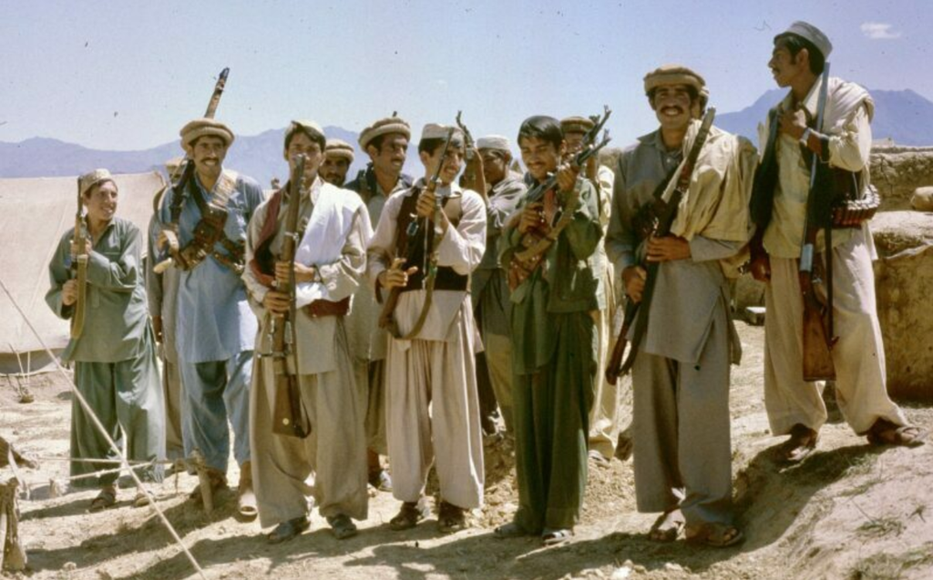

[figure not shown]

[figure not shown]

[figure not shown]

## Foreign fighters

- **foreign fighters** - individuals who travel to a conflict zone from another territory (prima facie evidence of radicalism $\rightarrow$ *engagement* in political violence; a ‘security failure’ by authority of origin state?)
- examples historically? from cases you know of?

FF is a widespread part and enduring element of political violence across the world

# Poll: foreign fighters

[figure not shown]

Take the survey at **https://forms.gle/JJ7ufLwrLJYKAbvg8**

- should states have laws banning travel to conflict zones?
- most effective for addressing foreign fighters phenomenon?
- top policy priority for dealing with returning fighters?
- are returning foreign fighters a significant threat?
- should states be able to revoke fighters’ citizenship?

Questions about groups: (1) Did the group emerge in response to political repression? (2) Did the absence of (opportunity for) peaceful political participation contribute to the group’s use of violence? (3) Did the group actively recruit members from outside its primary country of operation? (4) How important were cross-border networks to this group’s activities? (5) Was the group’s cause was framed as an international struggle?

[interactive chart not shown]

group emerged in response to repression?

[interactive chart not shown]

lack of peaceful participation led to group’s use of violence

[interactive chart not shown]

## Group responses - external connections

group recruited from outside primary country?

[interactive chart not shown]

cross-border networks importance?

[interactive chart not shown]

## Group responses - framing of violence

group’s cause framed as an international struggle rather than local?

[interactive chart not shown]

# Who becomes a foreign fighter, how are returnees addressed

- Morris (2023) - Who Becomes a Foreign Fighter? Characteristics of the Islamic State’s Soldiers
  - context, casing, data, locales of fighter mobilisation
  - results and findings
- dealing with returning foreign fighters

## Morris (2023) - Context

**MENA (Middle East, North Africa) countries have sent the largest numbers of foreign fighters to Syria**

- Why is this the case? What are the relevant contextual factors?

## Morris (2023) - Context

**MENA (Middle East, North Africa) countries have sent the largest numbers of foreign fighters to Syria**

- Why is this the case? What are the relevant contextual factors?
  - religious ideology (*jihad*)
  - religious internationalism (history of MENA alliance, e.g., in wars and campaigns against Israel)
  - contexts of deprivation? travelling to fight as a ‘way out’

## Morris (2023) - Casing

- Three countries analysed: **Morocco**, **Egypt**, and **Turkey**
  - Morocco represents foreign fighters from the Maghreb (Northwest Africa). (**representative country context**)
  - Egyptian foreign fighters are more alike to ISIS recruits from the Levant than North Africa. (**representative country context**)
  - Turkey,
    - Turkey’s historical, political, and socioeconomic traits make it as a (**least likely mobilisation context**)
    - Turkish foreign fighters may be more like Islamic State members from the Middle East and Central Asia than the other two countries. (**representative country context**)
- NB: Two casing logics at work here: (1) thinking in terms of population of foreign fighters and clusters therein and (2) thinking in terms of country cases in comparison with other country cases

## Morris (2023) - data

- data from leaked IS personnel records
- explanatory variables
  - **occupation**: unemployed, unskilled, student, skilled
  - **education**: none, primary, secondary, university
  - **marital status**: single, married
  - **children**: yes, no
  - **age**
- any major factors that seem omitted?

## Morris (2023) - locales of fighter mobilisation

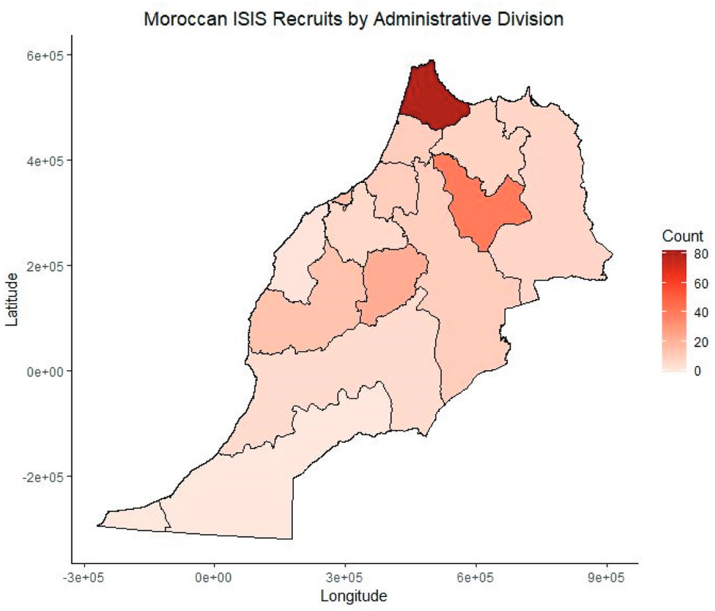

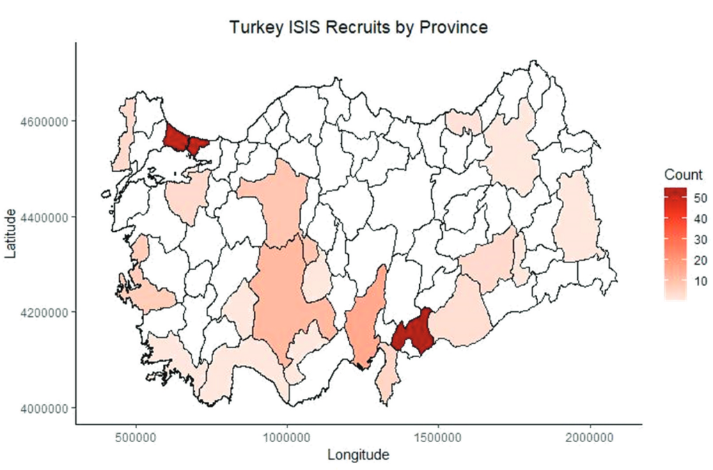

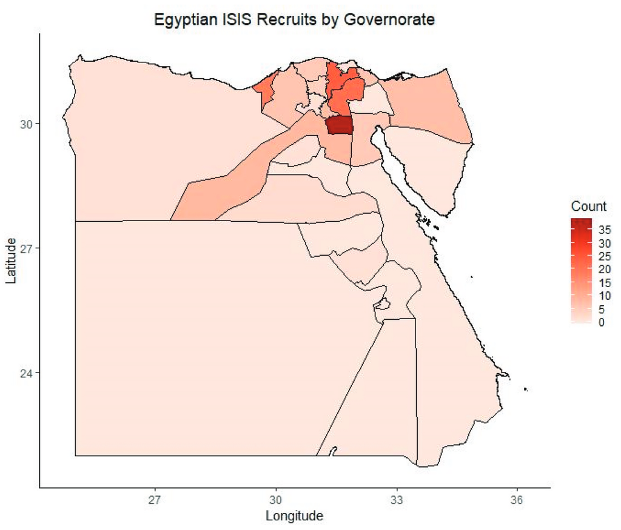

*Major centres*: Tangier, Tetouan, and surrounding region, and Fes; Cairo, Alexandria, and lower Nile area; Istanbul and Antep

any visualisation problems?

## Morris (2023) - regression results (*how to interpret*?)

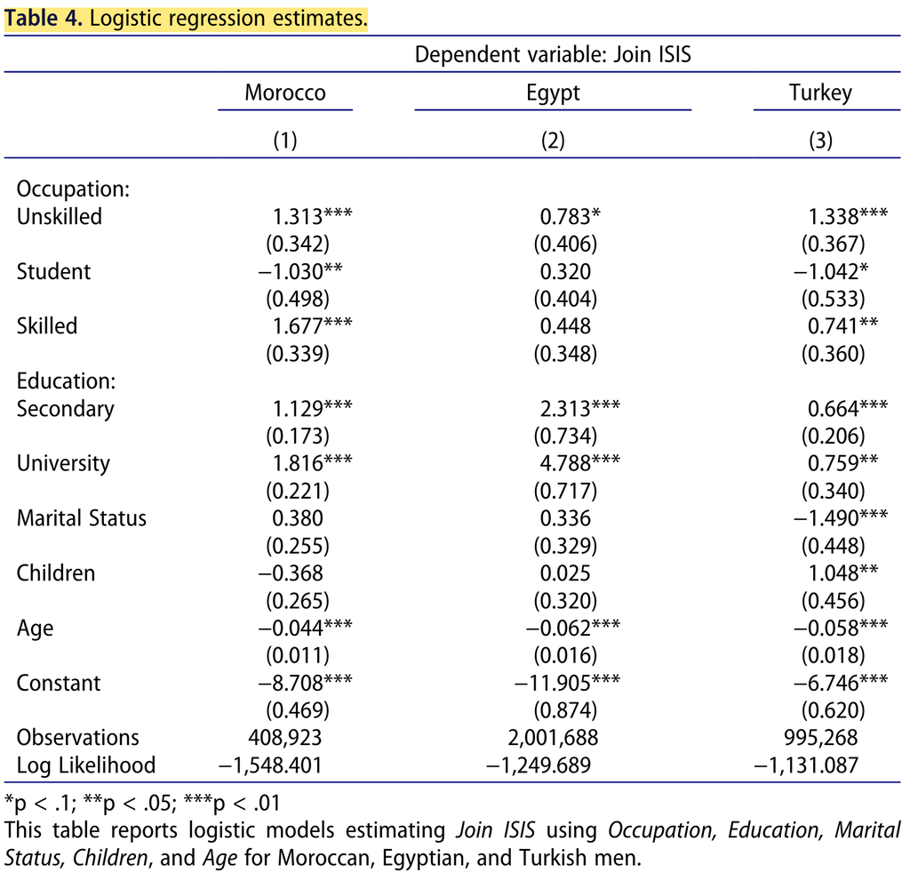

## Reading a regression table

Remember: regression is a tool for understanding a phenomenon as a linear function (generally) → (y = mx + b)

1. Numbers not in parentheses next to a variable: **regression coefficient**: expected change in DV for a one-unit increase in IV. NB: ositive or negative relationship?
2. Numbers inside parentheses next to a variable: **standard error**: estimate of the standard deviation of the coefficient
3. Asterisks/‘stars’: **statistical significance**: probability of results as extreme as observed result, under the assumption that the null hypothesis is correct. Smaller p-value means such an observation would be less likely under null hypothesis; hence, significance. Statistical significance suggests more precise estimates—NOT necessarily that one IV is more important than another.

## Morris (2023) - regression results (*how to interpret*?)

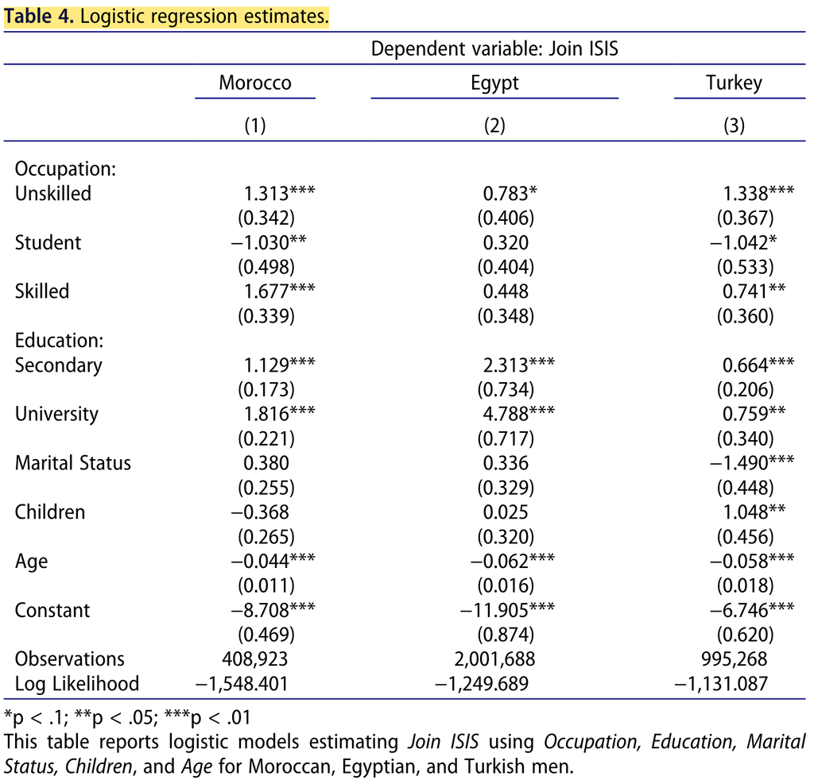

## Morris (2023) - regression results

[figure not shown]

## Findings

> Despite the difference in space and time, ISIS foreign fighters have a similar profile to members of Hamas, Hezbollah, the Palestinian Islamic Jihad, and even violent political activists in Bengal. The men in all these samples are predominately **male**, **well-educated**, **urban**, **unmarried**, and **young**.

## Poll results - dealing with potential FFs

laws banning travel to conflict zones?

[interactive chart not shown]

most effective for addressing foreign fighters phenomenon?

[interactive chart not shown]

## Dealing with returning foreign fighters (1)

Spain example

[video not shown]

## Dealing with returning foreign fighters (2)

Economist (a bit sensationalist and some graphic imagery)

[video not shown]

## Dealing with returning foreign fighters (3)

David Malet

[video not shown]

## Poll results - returning foreign fighters

top policy priority for dealing with returning fighters?

[interactive chart not shown]

are returning foreign fighters a significant threat?

[interactive chart not shown]

should states be able to revoke fighters’ citizenship?

[interactive chart not shown]

# Political violence in an authoritarian contexts

- questions
- Enstad (2018) - Right-Wing Terrorism and Violence in Putin’s Russia
  - data overview

[Authoritarian Wayne'S World GIF](https://tenor.com/view/authoritarian-wayne%27s-world-mike-meyers-asphinctersayswhat-gif-1285984849164287010)from [Authoritarian GIFs](https://tenor.com/search/authoritarian-gifs)

## Political violence in an authoritarian context

**What are the special conditions of political violence in within an authoritarian regime?**

- more extreme possibilities of repression
- against the state or against others?
- combatted by, tolerated by, or supported by the state?

## Enstad (2018) - an empirical puzzle?

> Putin’s Russia has seen much more right-wing violence than any other comparable country in the past 25 years.

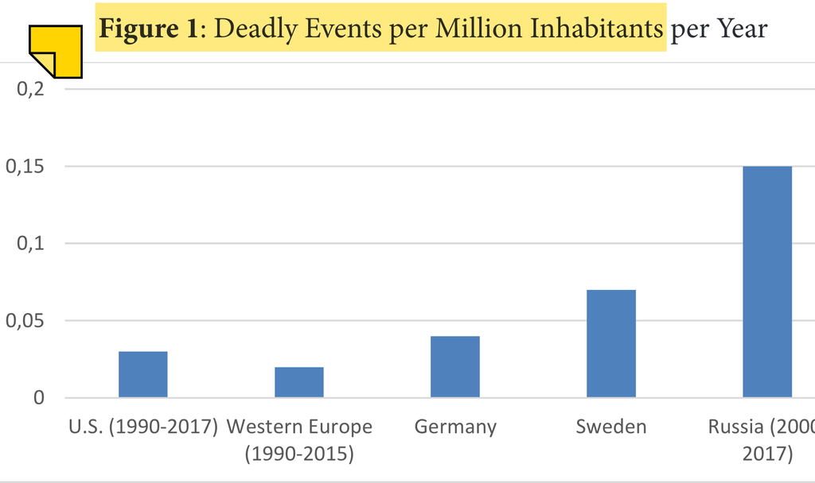

## Enstad (2018) - aim and data

- descriptive research aim: comparison of countries and regions, patterns and trends

> The RTV-RUSSIA dataset currently consists of 495 events, including 406 deadly events causing 459 deaths over a period of eighteen years (2000-2017). RTV-RUSSIA has been patterned on the RTV dataset (RightWing Terrorism and Violence in Western Europe) compiled by Jacob Ravndal,[4] and features the same set of variables (date, location, event type, perpetrator type, perpetrator’s organizational affiliation, victim, weapon(s) used, number of casualties, as well as a description of the event).

## Enstad (2018) - data overview

[output not shown]

## Enstad (2018) - region comparison

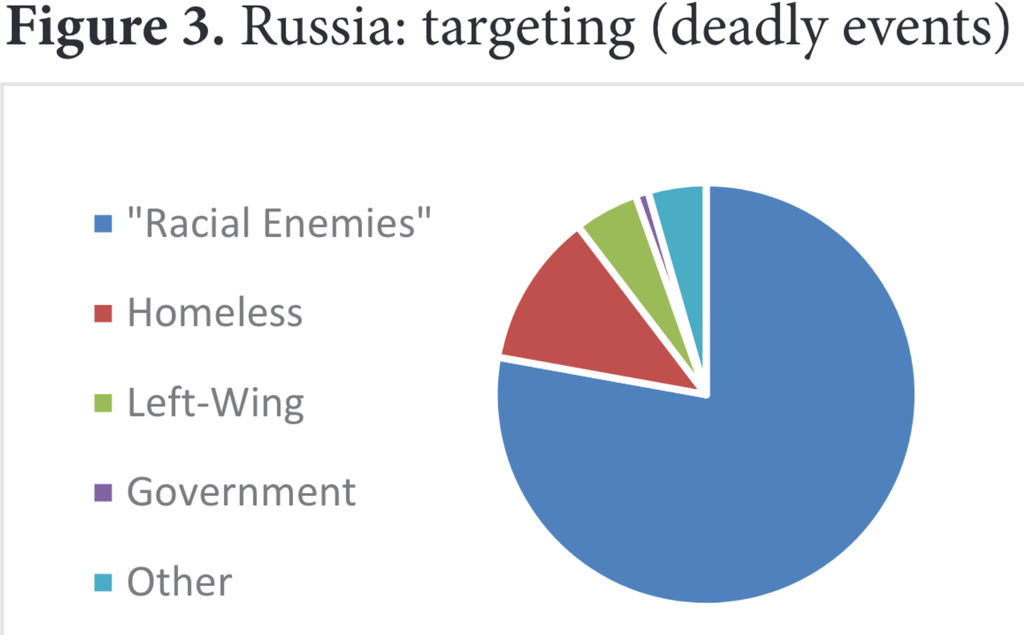

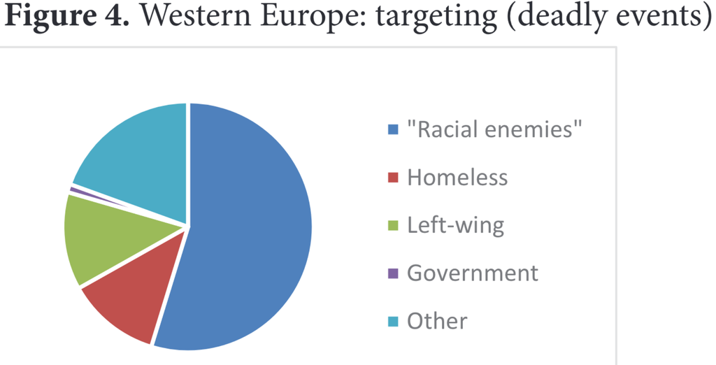

## Enstad (2018) - longitudinal comparison

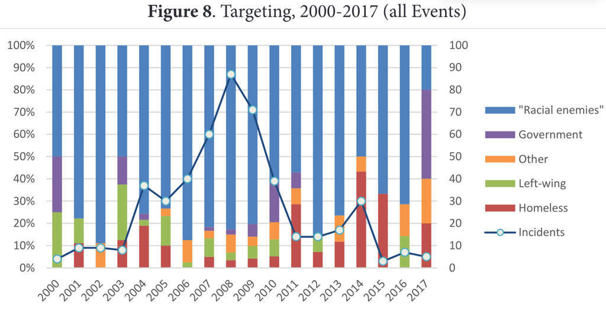

## Enstad (2018) - findings

1. **Russian activists have operated much more violently** compared to their counterparts in the United States and Western Europe.
2. Russian activists have operated **more purposefully**, with premeditated attacks vastly outnumbering spontaneous ones.
3. gangs and unorganized groups have been the most common perpetrators; the overall **share of lone actors has been much lower than in the West**

# Any questions, concerns, feedback for this class?

Anonymous feedback here: https://forms.gle/NfF1pCfYMbkAT3WP6

Alternatively, please send me an email: m.zeller@lmu.de

Questions about groups next meeting: (1) Does the group’s violence increase around elections? (2) How is the group’s violence connected to elections? (3) Has the group intimidated/targeted voters? (4) Has the group intimidated/targeted candidates/office-holders?

## References

Enstad, Johannes Due. 2018. “Right-Wing Terrorism and Violence in Putin’s Russia.” *Perspectives on Terrorism* 12 (6): 89–103.

Morris, Andrea Michelle. 2023. “Who Becomes a Foreign Fighter? Characteristics of the Islamic State’s Soldiers.” *Terrorism and Political Violence*, January, 1–19. https://doi.org/10.1080/09546553.2022.2144730.